# Entrega descubrimiento subgrupos

# 1.Introducción

El objetivo del presente trabajo es analizar el dataset “Crime Data from 2020 to Present” (descarga disponible en: https://data.lacity.org/Public-Safety/Crime-Data-from-2020-to-Present/2nrs-mtv8), mediante técnicas de descubrimiento de subgrupos. El dataset a estudiar refleja los incidentes de delincuencia en la ciudad de Los Ángeles desde 2020 a la actualidad. Estos datos se transcriben a partir de informes originales de delitos que se escriben en papel y, por lo tanto, puede haber algunas inexactitudes en los datos. Algunos campos de ubicación con datos faltantes se anotan como (0°, 0°). Los campos de dirección solo se proporcionan con una precisión de cien manzanas para mantener la privacidad.

# 2.Importado y limpieza de los datos

Procedemos a importar y limpiar los datos. Imprimimos los primeros 5 registros, de manera de tener una primera aproximación a los datos:

```r
df= read.csv("Crime_Data_from_2020_to_Present.csv", sep =",", header = T)
head(df)
```

|  | DR_NO | Date.Rptd | DATE.OCC | TIME.OCC | AREA | AREA.NAME | Rpt.Dist.No | Part.1.2 | Crm.Cd | Crm.Cd.Desc | Mocodes | Vict.Age | Vict.Sex | Vict.Descent | Premis.Cd | Premis.Desc | Weapon.Used.Cd | Weapon.Desc | Status | Status.Desc | Crm.Cd.1 | Crm.Cd.2 | Crm.Cd.3 | Crm.Cd.4 | LOCATION | Cross.Street | LAT | LON |
| --- | --- | --- | --- | --- | --- | --- | --- | --- | --- | --- | --- | --- | --- | --- | --- | --- | --- | --- | --- | --- | --- | --- | --- | --- | --- | --- | --- | --- |
| 1 | 10304468 | 01/08/2020 12:00:00 AM | 01/08/2020 12:00:00 AM | 2230 | 3 | Southwest | 377 | 2 | 624 | BATTERY - SIMPLE ASSAULT | 0444 0913 | 36 | F | B | 501 | SINGLE FAMILY DWELLING | 400 | STRONG-ARM (HANDS, FIST, FEET OR BODILY FORCE) | AO | Adult Other | 624 | NA | NA | NA | 1100 W 39TH PL |  | 34.0141 | -118.2978 |
| 2 | 190101086 | 01/02/2020 12:00:00 AM | 01/01/2020 12:00:00 AM | 330 | 1 | Central | 163 | 2 | 624 | BATTERY - SIMPLE ASSAULT | 0416 1822 1414 | 25 | M | H | 102 | SIDEWALK | 500 | UNKNOWN WEAPON/OTHER WEAPON | IC | Invest Cont | 624 | NA | NA | NA | 700 S HILL ST |  | 34.0459 | -118.2545 |
| 3 | 191501505 | 01/01/2020 12:00:00 AM | 01/01/2020 12:00:00 AM | 1730 | 15 | N Hollywood | 1543 | 2 | 745 | VANDALISM - MISDEAMEANOR ($399 OR UNDER) | 0329 1402 | 76 | F | W | 502 | MULTI-UNIT DWELLING (APARTMENT, DUPLEX, ETC) | NA |  | IC | Invest Cont | 745 | 998 | NA | NA | 5400 CORTEEN PL |  | 34.1685 | -118.4019 |
| 4 | 191921269 | 01/01/2020 12:00:00 AM | 01/01/2020 12:00:00 AM | 415 | 19 | Mission | 1998 | 2 | 740 | VANDALISM - FELONY ($400 & OVER, ALL CHURCH VANDALISMS) | 0329 | 31 | X | X | 409 | BEAUTY SUPPLY STORE | NA |  | IC | Invest Cont | 740 | NA | NA | NA | 14400 TITUS ST |  | 34.2198 | -118.4468 |
| 5 | 200100501 | 01/02/2020 12:00:00 AM | 01/01/2020 12:00:00 AM | 30 | 1 | Central | 163 | 1 | 121 | RAPE, FORCIBLE | 0413 1822 1262 1415 | 25 | F | H | 735 | NIGHT CLUB (OPEN EVENINGS ONLY) | 500 | UNKNOWN WEAPON/OTHER WEAPON | IC | Invest Cont | 121 | 998 | NA | NA | 700 S BROADWAY |  | 34.0452 | -118.2534 |
| 6 | 200100502 | 01/02/2020 12:00:00 AM | 01/02/2020 12:00:00 AM | 1315 | 1 | Central | 161 | 1 | 442 | SHOPLIFTING - PETTY THEFT ($950 & UNDER) | 1402 2004 0344 0387 | 23 | M | H | 404 | DEPARTMENT STORE | NA |  | IC | Invest Cont | 442 | 998 | NA | NA | 700 S FIGUEROA ST |  | 34.0483 | -118.2631 |

```r
str(df)
```

[output not shown]

Se observa que el archivo contiene 436.096 registros y 28 variables que se describen a continuación:

*DR_NO*: Número de registro compuesto por 2 digitos para el año, el ID del área, y 5 digitos.

*Date Rptd*: Fecha de reporte.

*DATE OCC*: Fecha del hecho.

*TIME OCC*: Horario del hecho.

*AREA*: Código de identificación de las 21 áreas policiales de LA.

*AREA NAME*: Nombre del área.

*Rpt Dist No*: Código de cuatro dígitos que representa una sub-área.

*Part 1-2*: Clasificación por tipo de crimen. Part 1 = crimenes violentos y contra la propiedad.

*Crm Cd*: Código del crimen.

*Crm Cd Desc*: Define el código del crimen.

*Mocodes*: Modus operandi.

*Vict Age*: Edad de la víctima.

*Vict Sex*: Sexo de la víctima.

*Vict Descent*: Ascendencia de la víctima.

*Premis Cd*: Tipo de estructura, vehículo, o locación donde el crimen tuvo lugar (código).

*Premis Desc*: Define el código de local proporcionado.

*Weapon Used Cd*: Código del tipo de arma utilizada en el crimen.

*Weapon Desc*: Define el código del tipo de arma.

*Status*: Código de estado del caso, IC es la opción por defecto.

*Status Desc*: Define el código del estado del caso.

*Crm Cd 1*: Indica el delito cometido. El código del delito 1 es el principal y más grave. Los códigos de delito 2, 3 y 4 son, respectivamente, delitos menos graves. Los números de clase de delito más bajos son más graves.

*Crm Cd 2*: Puede contener un código para un delito adicional, menos grave que el código del delito 1.

*Crm Cd 3*: Puede contener un código para un delito adicional menos grave.

*Crm Cd 4*: Puede contener un código para un delito adicional menos grave.

*LOCATION*: Dirección del incidente delictivo redondeada a la centena de manzanas más cercana para mantener el anonimato.

*Cross Street*: Calle transversal redondeada.

*LAT*: Latitud.

*LON*: Longitud.

Para un mayor detalle de la clasificación, ver el *ucr_handbook_2013.pdf*, disponible en la página de origen de los datos.

A continuación, procedemos a eliminar las columnas que no nos resultan de utilidad para el armado de subgrupos. En particular, se han eliminado muchas columnas que contienen códigos de identificación, puesto que se cuenta con columnas con la descripción de los mismos, siendo estos de mayor utilidad. Asimismo, se ha eliminado la columna de identificación unívoca de cada registro, así como los campos de fecha de reporte del hecho, fecha de ocurrencia, la latitud, y la longitud, puesto que no se utilizarán para el armado de subgrupos. Se eliminan también *Crm.Cd.1*, ya que duplica información de *Crm.Cd*, y los campos *Crm.Cd.2*, *Crm.Cd.3*, y *Crm.Cd.4*, puesto que para la mayoría de los registros no hay valor asignado. *Rpt.Dist-No* se elimina porque hay demasiados valores únicos para dicho campo (1.183 valores posibles) y ya se cuenta con el campo *AREA.NAME* para identificar geográficamente los hechos.

A modo de resumen, los campos eliminados son: *DR_NO*, *Date.Rptd*, *DATE.OCC*, *AREA*, *Rpt.Dist.No*, *Part.1.2*, *Crm.Cd.Desc*, *Premis.Cd*, *Weapon.Desc*, *Status*, *Crm.Cd.1*, *Crm.Cd.2*, *Crm.Cd.3*, *Crm.Cd.4*, *Cross.Street*, *LAT*, y *LON*.

```r
df2=df
df2$DR_NO= NULL
df2$DATE.OCC= NULL
df2$Date.Rptd = NULL
df2$AREA = NULL
df2$Rpt.Dist.No = NULL
df2$Part.1.2 = NULL
df2$Crm.Cd.Desc = NULL
df2$Premis.Cd = NULL
df2$Weapon.Desc = NULL
df2$Status = NULL
df2$Crm.Cd.1 = NULL
df2$Crm.Cd.2 = NULL
df2$Crm.Cd.3 = NULL
df2$Crm.Cd.4 = NULL
df2$Cross.Street = NULL
df2$LAT = NULL
df2$LON = NULL
```

A continuación, se procede a agrupar los datos en rangos que sean de mayor interés para el armado de subgrupos.

Agrupamos los datos en *madrugada* [00-06), *mañana* [06-12), *tarde* [12-19), y *noche* [19-00):

```r
df2= df2 %>% mutate(TIME.OCC = case_when(TIME.OCC >= 0 & TIME.OCC < 600 ~ "madrugada",
                                         TIME.OCC >= 600 & TIME.OCC < 1200 ~ "mañana",
                                         TIME.OCC >= 1200 & TIME.OCC < 1900 ~ "tarde",
                                         TIME.OCC >= 1900 & TIME.OCC <= 2359 ~ "noche"))
```

Agrupamos la edad de la víctima en *menor* [1-18), *joven* [18-64), y *mayor* [65 o más).

A las personas con edad 0 y -1 se las categoriza como *excluir*, ya que se trata de errores de carga o faltantes de información.

```r
df2= df2 %>% mutate(Vict.Age = case_when(Vict.Age >= 1 & Vict.Age < 18 ~ "menor",
                                         Vict.Age >= 18 & Vict.Age < 65 ~ "joven",
                                         Vict.Age >= 65 ~ "mayor",
                                         TRUE ~ "excluir"))
```

En el caso de las armas se clasifican en *arma_de_fuego* (100-199), *cortante* (200-299), *otras_peligrosas* (300-399), *fisico* (400-499), *desconocida_y_otras* (500-599), y *no_reportado*.

```r
df2 = df2 %>% mutate(Weapon.Used.Cd = case_when(Weapon.Used.Cd >= 100 & Weapon.Used.Cd <= 199 ~ "arma_de_fuego",
                                         Weapon.Used.Cd >= 200 & Weapon.Used.Cd <= 299 ~ "cortante",
                                         Weapon.Used.Cd >= 300 & Weapon.Used.Cd <= 399 ~ "otras_peligrosas",
                                         Weapon.Used.Cd >= 400 & Weapon.Used.Cd <= 499 ~ "fisico",
                                         Weapon.Used.Cd >= 500 & Weapon.Used.Cd <= 599 ~ "desconocida_y_otras",
                                         TRUE ~ "no_reportado"))
```

En el caso del campo *Vict.Descent*, se procede a reemplazar los códigos, de manera tal que en vez de letras figure la descripción. De igual modo, se clasifican las 58.312 líneas que no poseen asignación, las clasificadas como desconocidas, u *other*, como dentro de *Unknown/not_reported/other*. Decidimos agrupar en *Pacific_Islander* a *Samoan*, *Guamanian* y *Hawaiian*. Asimismo, se ha hecho lo análogo con *Asian Indian*, a quienes hemos agrupado en *American_Indian/Alaskan_Native*. En la categoría *Asian* se han incluido *other_asian*, *Chinese*, *Cambodian*, *Filipino*, *Japanese*, *Korean*, *Laotian*, y *Vietnamese*.

```r
df2= df2 %>% mutate(Vict.Descent = case_when(Vict.Descent == "A" ~ "Asian",
                                         Vict.Descent == "B" ~ "black",
                                         Vict.Descent == "C" ~ "Asian",
                                         Vict.Descent == "D" ~ "Asian",
                                         Vict.Descent == "F" ~ "Asian",
                                         Vict.Descent == "G" ~ "Pacific_Islander",
                                         Vict.Descent == "H" ~ "Hispanic/Latin/Mexican",
                                         Vict.Descent == "I" ~ "American_Indian/Alaskan_Native",
                                         Vict.Descent == "J" ~ "Asian",
                                         Vict.Descent == "K" ~ "Asian",
                                         Vict.Descent == "L" ~ "Asian",
                                         Vict.Descent == "O" ~ "Unknown/not_reported/other",
                                         Vict.Descent == "P" ~ "Pacific_Islander",
                                         Vict.Descent == "S" ~ "Pacific_Islander",
                                         Vict.Descent == "U" ~ "Pacific_Islander",
                                         Vict.Descent == "V" ~ "Asian",
                                         Vict.Descent == "W" ~ "White",
                                         Vict.Descent == "X" ~ "Unknown/not_reported/other",
                                         Vict.Descent == "Z" ~ "American_Indian/Alaskan_Native",
                                         TRUE ~ "Unknown/not_reported/other"
                                         ))
```

Agrupamos los *Crm.Cd*. En el caso de *Violencia doméstica*, si bien se trata de un subnivel dentro de *Asalto agravado* y *Asalto simple*, debido a su relevancia, se ha decidido elevarla en su nivel de jerarquía.

La identificación *VC* corresponde a crímenes violentos, mientras que *PC* son crímenes contra la propiedad.

Si bien para clasificar gran parte de los datos se ha utilizado el documento *UCR-COMPSTAT062618.pdf*, hay 106.682 registros no incluidos (descripciones que comienzan con la palabra ‘otros’). Se ha procedido a realizar una inspección manual de dichos códigos de manera de poder asignarlos correctamente.

```r
df2= df2 %>% mutate(Crm.Cd2 = case_when(Crm.Cd == 110  | Crm.Cd == 113 ~ "VC_homicidio",
                                         Crm.Cd == 121 | Crm.Cd == 122 | Crm.Cd == 815 | Crm.Cd == 820 | Crm.Cd == 821 ~ "violacion",
                                         Crm.Cd == 210 | Crm.Cd == 220 ~ "VC_robo",
                                         Crm.Cd == 510 | Crm.Cd == 520 | Crm.Cd == 433 ~ "VC_robo_vehiculo",
                                         Crm.Cd == 230 | Crm.Cd == 231 | Crm.Cd == 235 ~ "VC_asalto_agravado",
                                         Crm.Cd == 236 | Crm.Cd == 250 | Crm.Cd == 251 | Crm.Cd == 761 | Crm.Cd == 926 ~ "VC_violencia_domestica_asalto_agravado",
                                         Crm.Cd == 435 | Crm.Cd == 436 | Crm.Cd == 437 | Crm.Cd == 622 | Crm.Cd == 623 | Crm.Cd == 624 | Crm.Cd == 625 ~ "VC_asalto_simple",
                                         Crm.Cd == 626 | Crm.Cd == 627 | Crm.Cd == 647 | Crm.Cd == 763 | Crm.Cd == 928 | Crm.Cd == 930 ~ "VC_violencia_domestica_asalto_simple",
                                         Crm.Cd == 310 | Crm.Cd == 320 ~ "PC_robo",
                                         Crm.Cd == 330 | Crm.Cd == 331 | Crm.Cd == 410 | Crm.Cd == 420 | Crm.Cd == 421 ~ "PC_robo_interior_vehiculo",
                                         Crm.Cd == 350 | Crm.Cd == 351 | Crm.Cd == 352 | Crm.Cd ==353 | Crm.Cd ==450 | Crm.Cd == 451 | Crm.Cd == 452 | Crm.Cd == 453 ~ "PC_robo_personal",
                                         Crm.Cd == 341 | Crm.Cd == 440 | Crm.Cd == 441 | Crm.Cd == 480 | Crm.Cd == 485 | Crm.Cd == 487 | Crm.Cd == 491 ~ "PC_otros_robos",
                                        Crm.Cd == 343 | Crm.Cd == 345 | Crm.Cd == 442 | Crm.Cd ==443 | Crm.Cd == 444 | Crm.Cd ==445 | Crm.Cd == 470 | Crm.Cd == 471 | Crm.Cd == 472 | Crm.Cd == 473 | Crm.Cd == 474 | Crm.Cd == 475  ~ "PC_robo_tienda",
                                        Crm.Cd == 745 | Crm.Cd == 740 ~ "otros_vandalismo",
                                        Crm.Cd == 888 | Crm.Cd == 880 ~ "otros_intrusion",
                                        Crm.Cd == 886 ~ "otros_disturbar_paz",
                                        Crm.Cd == 860 ~ "otros_agresión_contacto_sexual",
                                        Crm.Cd == 946 | Crm.Cd == 850 | Crm.Cd == 890 | Crm.Cd == 806 | Crm.Cd == 949 | Crm.Cd == 948 | Crm.Cd == 924 | Crm.Cd == 830 | Crm.Cd == 931 | Crm.Cd == 884 ~ "no_codificado",
                                        Crm.Cd == 648 ~ "otros_piromano",
                                        Crm.Cd == 354 ~ "otros_robo_identidad",
                                        Crm.Cd == 662 | Crm.Cd== 664 | Crm.Cd== 668 | Crm.Cd== 649 | Crm.Cd== 653 | Crm.Cd== 670  | Crm.Cd == 666 | Crm.Cd== 651 | Crm.Cd== 652 | Crm.Cd== 653 | Crm.Cd== 654 | Crm.Cd== 660 | Crm.Cd== 661 ~ "otros_estafa",
                                        Crm.Cd == 900 | Crm.Cd == 903 ~ "otros_tribunal",
                                        Crm.Cd == 902 | Crm.Cd == 901 ~ "otros_orden_alejamiento",
                                        Crm.Cd==956 ~ "otros_llamadas",
                                        Crm.Cd== 910 | Crm.Cd== 920 ~ "otros_secuestro_e_intento_secuestro",
                                        Crm.Cd == 755 ~ "otros_amenaza_bomba",
                                        Crm.Cd == 753 ~ "otros_disparo_arma",
                                        Crm.Cd == 762 ~ "otros_conducta_lasciva",
                                        Crm.Cd == 522 ~ "otros_bicicletas_scooters",
                                        Crm.Cd == 237 ~ "otros_negligencia_ninos",
                                        Crm.Cd == 940 ~ "otros_extorsion",
                                        Crm.Cd == 812 | Crm.Cd == 813 | Crm.Cd == 760 ~ "otros_crimenes_ninos",
                                        Crm.Cd == 814 ~ "otros_pornografia_infantil",
                                        Crm.Cd == 822 | Crm.Cd == 921 ~ "otros_tráfico_personas",
                                        Crm.Cd == 845 ~ "otros_delincuente_sexual_no_registrado",
                                        Crm.Cd == 922 ~ "otros_robo_ninos",
                                        Crm.Cd == 932 ~ "otros_miron",
                                        Crm.Cd == 434 ~ "otros_falso_encarcelamiento",
                                        Crm.Cd == 933 ~ "otros_merodeador",
                                        Crm.Cd == 434 ~ "otros_falso_encarcelamiento",
                                        Crm.Cd == 810 ~ "otros_sexo_ilegal",
                                        Crm.Cd == 438 ~ "otros_conduccion_temeraria",
                                        Crm.Cd == 439 ~ "otros_reporte_policial_falso",
                                        Crm.Cd == 944 ~ "otros_conspiracion",
                                        Crm.Cd == 954 ~ "otros_contributing",
                                        Crm.Cd == 943 | Crm.Cd == 840 ~ "otros_animales",
                                        Crm.Cd == 951 | Crm.Cd == 950 ~ "otros_robo_servicios",
                                        Crm.Cd == 805 ~ "otros_proxenetismo",
                                        Crm.Cd == 942 ~ "otros_soborno",
                                        Crm.Cd == 756 ~ "otros_posesion_armas",
                                        Crm.Cd == 347 ~ "otros_fraude_seguro",
                                        Crm.Cd == 349 | Crm.Cd== 446 ~ "otros_reparacion_auto",
                                        Crm.Cd == 870 ~ "otros_abandono_nino",
                                        Crm.Cd == 865 ~ "otros_droga_a_menores",
                                        Crm.Cd == 906 | Crm.Cd == 904 ~ "otros_portacion_armas",
                                        TRUE ~ "no_codificado"
                                        ))
```

A continuación se comprueba no hay presencia de *NA`s*

```r
colSums(is.na(df2))
```

```
      TIME.OCC      AREA.NAME         Crm.Cd        Mocodes       Vict.Age
             0              0              0              0              0
      Vict.Sex   Vict.Descent    Premis.Desc Weapon.Used.Cd    Status.Desc
             0              0              0              0              0
      LOCATION        Crm.Cd2
             0              0
```

# 3.Análisis exploratorio

Seguidamente, se observa la distribución de crímenes por momentos del día:

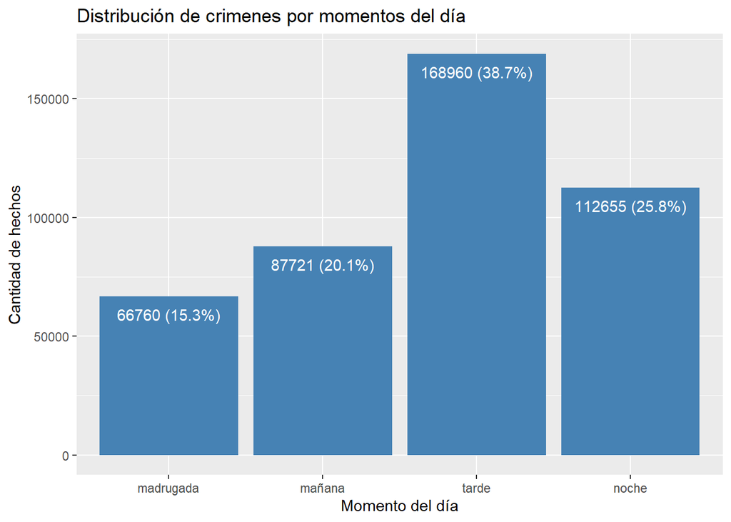

Se observa que la tarde es el momento del día en el que se producen la mayor parte de los hechos, con el 38.7% de los mismos, seguido por la noche con el 25.8%.

Sexo de las víctimas:

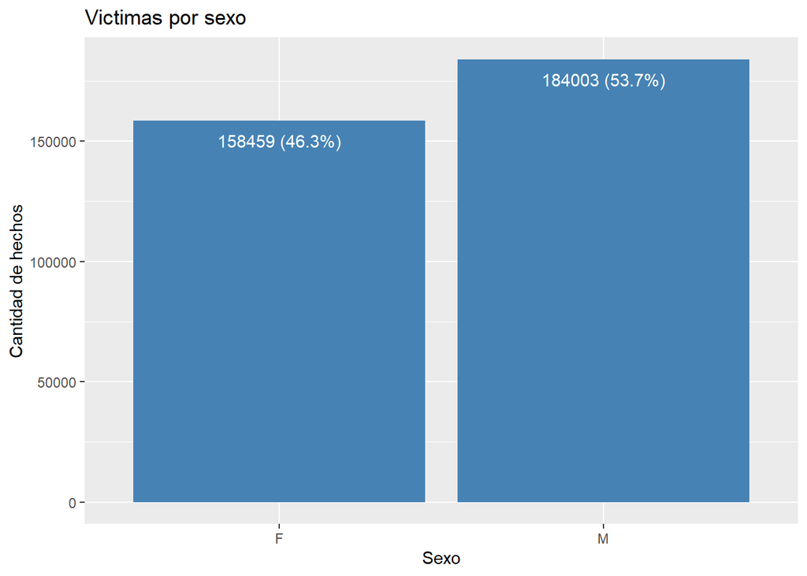

En cuanto al sexo de las victimas, para los casos en los que se ha reportado, se observa que el 53.7% han sido hombres.

Edad de las víctimas:

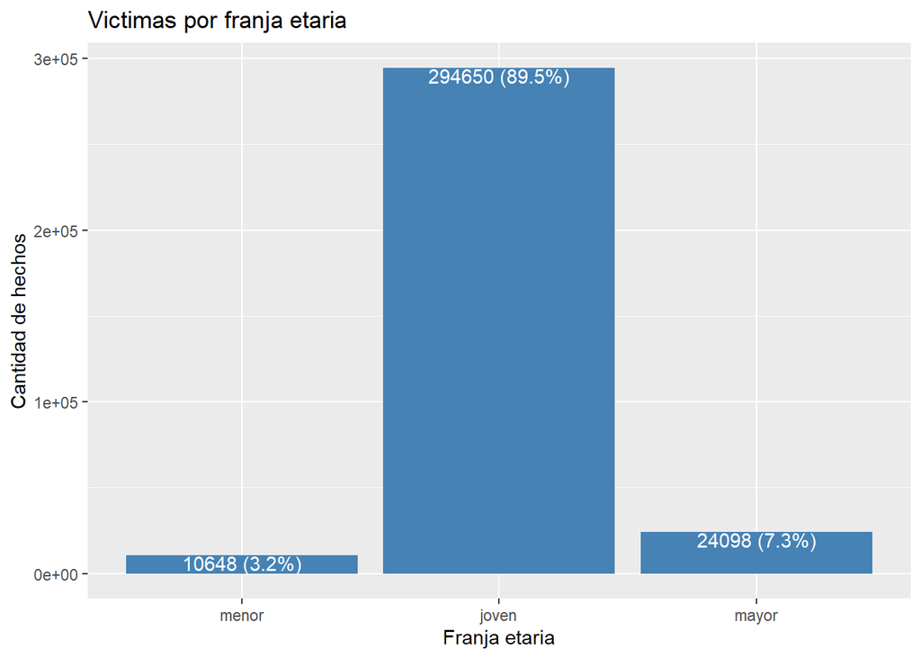

En cuanto a las franjas etarias, vemos que la abrumadora mayoría de las víctimas son jóvenes (89.5%). Esto es así, ya que dicha franja etaria aglutina a las personas entre 18 y 65 años, dejando a las categorías “menor” y “mayor”, con una menor representación de personas.

Relevamos la distribución de los crímenes por tipo de arma:

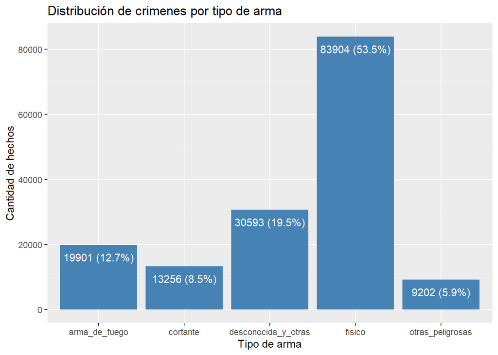

Se observa que la mayor parte de los crímenes que han reportado la casilla del arma utilizada, ocurren utilizando ataques físicos, en su mayoría (53.5%) seguido de armas desconocidas y otras (19.5%), y armas de fuego (12.7%)

Crímenes por Área:

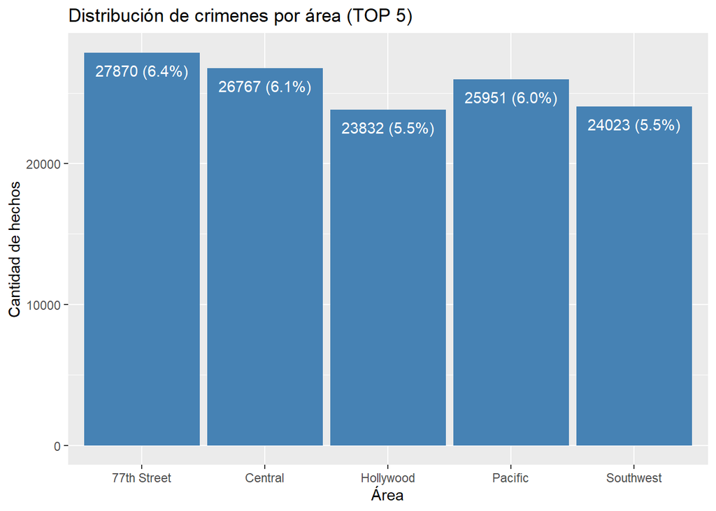

En cuanto al área del hecho, se observa que “77th Street” engloba el 6.4% de los hechos, seguido por “Central” con el 6.1%, y “Pacific” con 6%.

Crímenes por descendencia de la víctima:

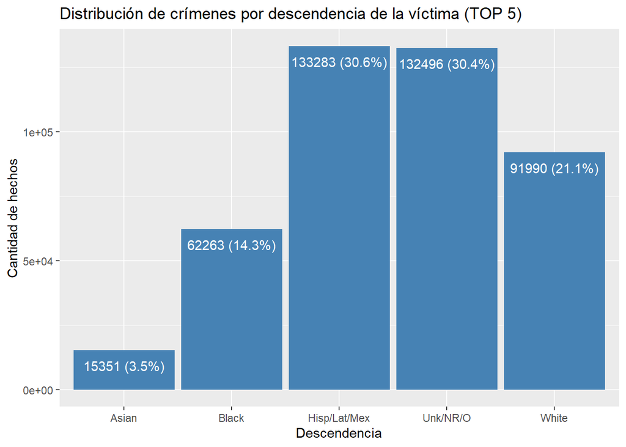

Se observa que la mayor parte de los hechos los sufren los “Hispanos/Latinos/Mexicanos” con un 30.6% de los hechos, seguido por los categorizados como “Blancos” con 21.1%, y personas de color, con 14,3%.

Hechos por tipo de crimen:

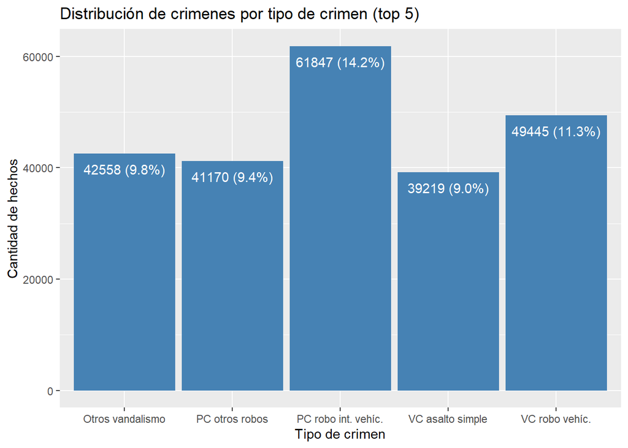

La visualización de datos arroja resultados significativos sobre los patrones de hechos más comunes. Se observa que el robo en interior de vehículos es la principal tipología, con un 14,2% del total, seguido por el robo del propio vehículo con un 11,3%, y por vandalismo con un 9.8%.

# 4.Descubrimiento de subgrupos

Se procede a convertir las variables a factor:

```r
df2$AREA.NAME = as.factor(df2$AREA.NAME)
df2$TIME.OCC = as.factor(df2$TIME.OCC)
df2$Vict.Sex = as.factor(df2$Vict.Sex)
df2$Vict.Age = as.factor(df2$Vict.Age)
df2$Vict.Descent = as.factor(df2$Vict.Descent)
df2$Crm.Cd2 = as.factor(df2$Crm.Cd2)
df2$Weapon.Used.Cd= as.factor(df2$Weapon.Used.Cd)
df2$Crm.Cd = as.factor(df2$Crm.Cd)
```

Para el descubrimiento de subgrupos, se procede a elegir a las *violaciones* como variable target dentro del campo *Crm.Cd*. Se incluyen los campos correspondientes al área, el momento del día en que ocurrió el hecho, el sexo de la víctima, su edad, y la etnia de la misma.

```r
#df_violacion= df2[!(df2$Vict.Age=="excluir"),]

#df_violacion= df_violacion[!(df_violacion$Vict.Sex=="X" | df_violacion$Vict.Sex=="H" | #df_violacion$Vict.Sex == ""),]

#df_violacion= df_violacion[!(df_violacion$Vict.Descent=="Unknown/not_reported/other"),]

#resultado=DiscoverSubgroups(df2,as.target("Crm.Cd2", "violacion"),new("SDTaskConfig",attributes=c("AREA.NAME","TIME.OCC","Vict.Sex","Vict.Age","Vict.Descent")))
#violacion=ToDataFrame(resultado)

#write.csv(violacion,"violacion.csv")
read.csv("violacion.csv")
```

| X | quality | p | size | chi2 | description |
| --- | --- | --- | --- | --- | --- |
| 1 | 1672.03 | 0.02 | 158459 | 3973.51 | Vict.Sex=F |
| 2 | 1128.21 | 0.02 | 139355 | 1924.69 | Vict.Sex=F, Vict.Age=joven |
| 3 | 810.60 | 0.04 | 23406 | 4253.48 | TIME.OCC=madrugada, Vict.Sex=F |
| 4 | 740.55 | 0.02 | 65699 | 1409.17 | Vict.Descent=Hispanic/Latin/Mexican, Vict.Sex=F |
| 5 | 655.09 | 0.04 | 21201 | 3050.61 | TIME.OCC=madrugada, Vict.Sex=F, Vict.Age=joven |
| 6 | 606.21 | 0.06 | 10648 | 5072.39 | Vict.Age=menor |
| 7 | 589.10 | 0.02 | 66760 | 880.07 | TIME.OCC=madrugada |
| 8 | 572.38 | 0.10 | 6211 | 7672.33 | Vict.Age=menor, Vict.Sex=F |
| 9 | 545.92 | 0.02 | 46283 | 1032.91 | TIME.OCC=madrugada, Vict.Age=joven |
| 10 | 543.89 | 0.02 | 39027 | 1193.61 | TIME.OCC=noche, Vict.Sex=F |

[output cut: 10 more lines]

Observamos que la regla que obtiene una mejor medida calidad (quality 1672,03), es aquella en la que la víctima es mujer. Se pone de manifiesto que de los 158.459 casos en los que se cumple la regla, el 2% de los mismos se corresponde con una violación. En términos generales, se observa que ser mujer, joven, y que el horario sea de madrugada, forman parte de las reglas de mayor calidad. Destaca a su vez que el 10% de las víctimas mujeres y menores de edad, han sufrido una violación.

A continuación, elegimos analizar los subgrupos de los delitos vinculados al tráfico de personas, a los que hemos categorizado como “otros_tráfico_personas” (códigos 822 y 921). Las variables que se utilizarán para formar los subgrupos son los mismos a los recopilados en el subgrupo anterior.

```r
#df_trafico= df2[!(df2$Vict.Age=="excluir"),]

#df_trafico= df_trafico[!(df_trafico$Vict.Sex=="X" | df_trafico$Vict.Sex=="H" | df_trafico$Vict.Sex == ""),]

#df_trafico= df_trafico[!(df_trafico$Vict.Descent=="Unknown/not_reported/other" | df_trafico$Vict.Descent=="no_reportado"),]

#resultado=DiscoverSubgroups(df2,as.target("Crm.Cd2", "otros_tráfico_personas"),new("SDTaskConfig",attributes=c("AREA.NAME","TIME.OCC","Vict.Sex","Vict.Age","Vict.Descent")))

#trafico=ToDataFrame(resultado)
#write.csv(trafico,"trafico.csv")
read.csv("trafico.csv")
```

| X | quality | p | size | chi2 | description |
| --- | --- | --- | --- | --- | --- |
| 1 | 185.04 | 0.03 | 6211 | 8731.05 | Vict.Age=menor, Vict.Sex=F |
| 2 | 183.21 | 0.02 | 10648 | 5072.13 | Vict.Age=menor |
| 3 | 161.99 | 0.00 | 158459 | 408.28 | Vict.Sex=F |
| 4 | 126.37 | 0.01 | 11965 | 2154.22 | AREA.NAME=77th Street, Vict.Sex=F |
| 5 | 124.14 | 0.00 | 34290 | 765.67 | Vict.Descent=black, Vict.Sex=F |
| 6 | 120.23 | 0.00 | 27870 | 869.78 | AREA.NAME=77th Street |
| 7 | 111.66 | 0.05 | 2108 | 9245.18 | Vict.Age=menor, Vict.Descent=black |
| 8 | 111.17 | 0.09 | 1299 | 14844.84 | Vict.Age=menor, Vict.Descent=black, Vict.Sex=F |
| 9 | 110.28 | 0.10 | 1129 | 16799.44 | Vict.Age=menor, AREA.NAME=77th Street |
| 10 | 109.55 | 0.16 | 703 | 26596.57 | Vict.Age=menor, AREA.NAME=77th Street, Vict.Sex=F |

[output cut: 10 more lines]

En este caso, la primera regla obtenida posee una medida de calidad de 185. La regla indica que la víctima es menor de edad y mujer, con un tamaño de 6.211, de los cuales el 3% son víctimas de trata de personas. En términos generales, observamos que ser mujer, menor, que el área sea “77th Street”, y que la víctima sea de color, se encuentra presente entre las primeras reglas.

A continuación, se evalúan los subgrupos de las armas cortantes en relación con el tipo de crimen, el momento del día, el sexo de la víctima, y su edad.

```r
#df_cortante= df2[!(df2$Vict.Age=="excluir"),]

#df_cortante= df_cortante[!(df_cortante$Vict.Sex=="X" | df_cortante$Vict.Sex=="H" | df_cortante$Vict.Sex == ""),]

#df_cortante= df_cortante[!(df_cortante$Crm.Cd2=="no_codificado"),]

#df_cortante= df_cortante[!(df_cortante$Weapon.Used.Cd=="no_reportado"),]

#resultado=DiscoverSubgroups(df2,as.target("Weapon.Used.Cd", "cortante"),new("SDTaskConfig",attributes=c("Crm.Cd2","TIME.OCC","Vict.Sex","Vict.Age")))

#armas=ToDataFrame(resultado)
#write.csv(armas,"armas.csv")
read.csv("armas.csv")
```

| X | quality | p | size | chi2 | description |
| --- | --- | --- | --- | --- | --- |
| 1 | 4953.25 | 0.21 | 27034 | 32827.55 | Crm.Cd2=VC_asalto_agravado |
| 2 | 4484.47 | 0.23 | 23013 | 31301.87 | Crm.Cd2=VC_asalto_agravado, Vict.Age=joven |
| 3 | 3877.92 | 0.30 | 14379 | 36694.93 | Crm.Cd2=VC_violencia_domestica_asalto_agravado |
| 4 | 3741.70 | 0.22 | 19288 | 25767.55 | Crm.Cd2=VC_asalto_agravado, Vict.Sex=M |
| 5 | 3544.46 | 0.30 | 13210 | 33275.97 | Crm.Cd2=VC_violencia_domestica_asalto_agravado, Vict.Age=joven |
| 6 | 3498.15 | 0.05 | 151984 | 4193.21 | Vict.Sex=M, Vict.Age=joven |
| 7 | 3451.87 | 0.05 | 184003 | 3800.84 | Vict.Sex=M |
| 8 | 3417.64 | 0.24 | 16691 | 24688.54 | Crm.Cd2=VC_asalto_agravado, Vict.Sex=M, Vict.Age=joven |
| 9 | 2558.23 | 0.42 | 6539 | 34475.15 | Crm.Cd2=VC_violencia_domestica_asalto_agravado, Vict.Sex=M |
| 10 | 2509.53 | 0.04 | 294650 | 2235.87 | Vict.Age=joven |

[output cut: 10 more lines]

Seguidamente, se buscan los subgrupos para “PC_robo_personal”. Para ello, se emplean las mismas variables que en “otros_tráfico_personas”, con la salvedad de “AREA.NAME”.

```r
#df_robo_personal= df2[!(df2$Vict.Age=="excluir"),]

#df_robo_personal= df_robo_personal[!(df_robo_personal$Vict.Sex=="X" | df_robo_personal$Vict.Sex=="H" | df_robo_personal$Vict.Sex == ""),]

#df_robo_personal= df_robo_personal[!(df_robo_personal$Crm.Cd2=="no_codificado"),]

#df_robo_personal= df_robo_personal[!(df_robo_personal$Weapon.Used.Cd=="no_reportado"),]

#resultado=DiscoverSubgroups(df2,as.target("Crm.Cd2", "PC_robo_personal"),new("SDTaskConfig",attributes=c("TIME.OCC","Vict.Sex","Vict.Age","Vict.Descent")))

#robo_personal=ToDataFrame(resultado)
#write.csv(robo_personal,"robo_personal_1.csv")
read.csv("robo_personal_1.csv")
```

| X | quality | p | size | chi2 | description |
| --- | --- | --- | --- | --- | --- |
| 1 | 567.03 | 0.01 | 160335 | 557.95 | Vict.Sex=F |
| 2 | 510.86 | 0.01 | 141005 | 481.75 | Vict.Sex=F, Vict.Age=joven |
| 3 | 431.62 | 0.01 | 297867 | 341.56 | Vict.Age=joven |
| 4 | 279.03 | 0.01 | 62652 | 256.43 | Vict.Sex=F, TIME.OCC=tarde |
| 5 | 228.34 | 0.01 | 134760 | 98.65 | Vict.Descent=Hispanic/Latin/Mexican |
| 6 | 223.48 | 0.01 | 113791 | 104.73 | TIME.OCC=tarde, Vict.Age=joven |
| 7 | 220.25 | 0.01 | 66485 | 152.11 | Vict.Descent=Hispanic/Latin/Mexican, Vict.Sex=F |
| 8 | 213.86 | 0.01 | 53882 | 171.18 | Vict.Sex=F, TIME.OCC=tarde, Vict.Age=joven |
| 9 | 199.83 | 0.01 | 58992 | 138.33 | Vict.Descent=Hispanic/Latin/Mexican, Vict.Sex=F, Vict.Age=joven |
| 10 | 185.94 | 0.01 | 63020 | 113.32 | Vict.Descent=black |

[output cut: 10 more lines]

En términos generales vemos entre las primeras reglas, que hay una relación entre ser mujer, joven, y de descendencia hispana con que el crimen sea un robo personal. La primera regla pone de manifiesto que el 1% de los 160.335 casos que se corresponden fehacientemente a tener como víctima a una persona de género femenino, son hechos relativos a un robo personal. Al analizar la descendencia de la víctima son los afros e hispanoamericanos las categorías que más se repiten en las diversas reglas, siendo estos últimos los que figuran entre las primeras. Cabe reseñar, como a nuestra sorpresa, los datos han diferido de lo esperado en relación con la franja horaria, puesto que la tarde se antepone a la noche.

Finalmente, se trata de identificar los subgrupos con el robo en tiendas a través del área, momento del día, género y edad de la víctima, es decir, averiguar si la premisa establecida arroja resultados provechosos que permitan definir un criterio sobre dichos hechos. Las variables seleccionadas para llevar a cabo el estudio son “AREA.NAME”, “TIME.OCC”, “Vict.Sex” y “Vict.Age”.

```r
#df_robo_tienda_w= df2[!(df2$Vict.Age=="excluir"),]

#df_robo_tienda_w= df_robo_tienda_w[!(df_robo_tienda_w$Vict.Sex=="X" | df_robo_tienda_w$Vict.Sex=="H" | #df_robo_tienda_w$Vict.Sex == ""),]

#df_robo_tienda_w= df_robo_tienda_w[!(df_robo_tienda_w$Vict.Descent=="Unknown/not_reported/other" | #df_robo_tienda_w$Vict.Descent=="no_reportado"),]

#resultado=DiscoverSubgroups(df_robo_tienda_w,as.target("Crm.Cd2", "PC_robo_tienda"),new("SDTaskConfig",attributes=c("AREA.NAME","TIME.OCC","Vict.Sex","Vict.Age")))

#ToDataFrame(resultado)

#robo_tienda_w = ToDataFrame(resultado)
#write.csv(robo_tienda_w,"robo_tienda_w.csv")
read.csv("robo_tienda_w.csv")
```

| X | quality | p | size | chi2 | description |
| --- | --- | --- | --- | --- | --- |
| 1 | 527.37 | 0.01 | 100522 | 668.61 | TIME.OCC=tarde, Vict.Age=joven |
| 2 | 491.51 | 0.02 | 51242 | 910.98 | TIME.OCC=tarde, Vict.Sex=M, Vict.Age=joven |
| 3 | 471.33 | 0.01 | 135327 | 482.03 | Vict.Sex=M, Vict.Age=joven |
| 4 | 455.21 | 0.01 | 58281 | 707.26 | TIME.OCC=tarde, Vict.Sex=M |
| 5 | 451.07 | 0.01 | 115030 | 461.49 | TIME.OCC=tarde |
| 6 | 393.17 | 0.08 | 5534 | 4551.42 | AREA.NAME=Topanga, Vict.Sex=M, Vict.Age=joven |
| 7 | 388.67 | 0.07 | 6250 | 3947.86 | AREA.NAME=Topanga, Vict.Sex=M |
| 8 | 385.91 | 0.01 | 150966 | 320.66 | Vict.Sex=M |
| 9 | 377.66 | 0.04 | 10382 | 2276.28 | AREA.NAME=Topanga, Vict.Age=joven |
| 10 | 370.36 | 0.04 | 11860 | 1926.23 | AREA.NAME=Topanga |

[output cut: 10 more lines]

Las primeras reglas parecen indicar que hay resultados esclarecedores respecto a la franja horaria relacionada con estos incidentes, así como la edad y género de la víctima. La primera regla tiene una medida de calidad de 527,37, con un tamaño total de 100.522, de los cuales el 1% de los incidentes se corresponde a robos en tienda. La regla nuclea al subgrupo de hechos que ocurren por la tarde y con una víctima joven. Por otra parte, se identifican cuatro áreas entre las principales reglas: Mission, Topanga, Van Nuys y Wilshire.

A continuación se describen algunas reglas más allá de las de mayor calidad:

La regla 19 describe como el 2% de las 11.375 de las veces que ocurren incidentes en Mission y la víctima es joven, el hecho se vincula a un robo en tienda. Seguidamente, las reglas 12 y 13 mantienen cómo el 7% y 10% de 4.189 y 2.595 hechos respectivamente, de las ocasiones que ha sucedido el mismo hecho en Topanga y por la tarde, la víctima ha sido joven (regla 12) y hombre (regla 13). Análogamente, la regla número 11 mantiene que el 12% de los 2.276 que la cumplen, se trata de un robo en tienda. Esta regla se corresponde con un perfil joven, masculino, y en la franja horaria de la tarde.